# wifflepresentation slides

### Background

In the statistical analysis of observational data, propensity score matching (PSM) is a statistical matching technique that attempts to estimate the effect of a treatment, policy, or other intervention by accounting for the covariates that predict receiving the treatment. PSM attempts to reduce the bias due to confounding variables that could be found in an estimate of the treatment effect obtained from simply comparing outcomes among units that received the treatment versus those that did not. The technique was first published by Paul Rosenbaum and Donald Rubin in 1983,[1] and implements the Rubin causal model for observational studies.

The possibility of bias arises because the apparent difference in outcome between these two groups of units may depend on characteristics that affected whether or not a unit received a given treatment instead of due to the effect of the treatment per se. In randomized experiments, the randomization enables unbiased estimation of treatment effects; for each covariate, randomization implies that treatment-groups will be balanced on average, by the law of large numbers. Unfortunately, for observational studies, the assignment of treatments to research subjects is typically not random. Matching attempts to mimic randomization by creating a sample of units that received the treatment that is comparable on all observed covariates to a sample of units that did not receive the treatment.

We will illustrate our novel matching technique using major league baseball statistics from 2015. Our method directly finds suitable matches by finding nearest neightbors in the high dimensional feature space by means of KDTrees.

Grab the latest complete year of major league baseball team statistics. We will treat AL as being the "treatment", and NL as the "control." First get the 2015 AL complete Team batting from http://www.baseball-reference.com/leagues/AL/2015.shtml or http://www.baseball-reference.com/leagues/NL/2015.shtml

## 2015 American League Team Data

```python
IFrame("http://www.baseball-reference.com/leagues/AL/2015.shtml",width=700, height=350)
```

[interactive chart not shown]

## 2015 National League Team Data

```python
IFrame("http://www.baseball-reference.com/leagues/NL/2015.shtml",width=700, height=350)
```

[interactive chart not shown]

```python
dfal2015['League'] = 1
dfnl2015['League'] = 0
```

The columns that characterize each team

- **#Bat** Number of Players used in games
- **BatAge** Batters' average age, weighted by AB + Games Played
- **R/G** Runs Scored Per Game
- **G** Games Played
- **PA** Plate Appearances. When available, we use actual plate appearances from play-by-play game accounts. Otherwise estimated using AB + BB + HBP + SF + SH, which excludes catcher interference
- **AB** At Bats
- **R** Runs Scored
- **H** Hits
- **2B** Doubles Hit
- **3B** Triples Hit
- **HR** Home Runs Hit
- **RBI** Runs Batted In
- **SB** Stolen Bases
- **CS** Caught Stealing
- **BB** Bases on Balls/Walks
- **SO** Strikeouts
- **BA** Hits/At Bats
- **OBP** (H + BB + HBP)/(At Bats + BB + HBP + SF)
- **SLG** Total Bases/At Bats or (1B + 2*2B + 3*3B + 4*HR)/AB
- **OPS** On-Base + Slugging Percentage
- **OPS+**
- **TB** Total Bases
- **GDP** Double Plays Grounded Into
- **HBP** Times Hit by a Pitch
- **SH** Sacrifice Hits (Sacrifice Bunts)
- **SF** Sacrifice Flies
- **IBB** Intentional Bases on Balls
- **LOB** Runners Left On Base
- **#P_p** Number of pitchers used in games
- **PAge_p** Pithchers' average age
- **RA/G_p** Runs allowed per game
- **W_p** Wins
- **L_p** Losses
- **W-L%_p** Win-Loss Percentage
- **ERA_p** 9 * ER/ IP
- **G_p** Games Pitched
- **GS_p** Games Started
- **GF_p** Games finished
- **CG_p** Complete Game
- **tSho_p** Shutouts by a team, no runs allowed in a game by one or more pitchers.
- **cSho_p** Shutouts. No runs allowed and a complete game
- **SV_p** Saves
- **IP_p** Innings Pitched
- **H_p** Hits allowed
- **R_p** Runs allowed
- **ER_p** Earned Runs allowed
- **HR_p** Home Runs allowed
- **BB_p** Bases on Balls/Walks
- **IBB_p** Intentional Bases on Balls
- **SO_p** Strikeouts
- **HBP_p** Times a pitcher hit a batter
- **BK_p** Balks
- **WP_p** Wild Pitches
- **BF_p** Batters faced
- **ERA+_p** ERA adjusted to the player's ballpark
- **FIP+p** Fielding Independent Pitching
- **WHIP+p** (BB+H)/IP
- **H9_p** 9*H/IP
- **HR9_p** 9*HR/IP
- **BB9+p** 9*BB/IP
- **SO9_p** 9*SO/IP
- **SO/W_p** Strikeouts to Walks ratio
- **LOB_p** Runners Left on Base

```python
df2015.head()
```

| Tm | #Bat | BatAge | R/G | G | PA | AB | R | H | 2B | 3B | ... | ERA+_p | FIP_p | WHIP_p | H9_p | HR9_p | BB9_p | SO9_p | SO/W_p | LOB_p | League |
| --- | --- | --- | --- | --- | --- | --- | --- | --- | --- | --- | --- | --- | --- | --- | --- | --- | --- | --- | --- | --- | --- |
| BAL | 48 | 27.9 | 4.40 | 162 | 6007 | 5485 | 713 | 1370 | 246 | 20 | ... | 102 | 4.11 | 1.317 | 8.8 | 1.1 | 3.0 | 7.7 | 2.55 | 1088 | 1 |
| BOS | 51 | 28.3 | 4.62 | 162 | 6237 | 5640 | 748 | 1495 | 294 | 33 | ... | 100 | 4.17 | 1.356 | 9.2 | 1.1 | 3.0 | 7.6 | 2.55 | 1127 | 1 |
| CHW | 40 | 28.2 | 3.84 | 162 | 6070 | 5533 | 622 | 1381 | 260 | 27 | ... | 98 | 3.82 | 1.320 | 8.9 | 1.0 | 2.9 | 8.4 | 2.87 | 1122 | 1 |
| CLE | 49 | 27.9 | 4.16 | 161 | 6109 | 5439 | 669 | 1395 | 303 | 29 | ... | 115 | 3.62 | 1.186 | 8.0 | 1.0 | 2.7 | 8.8 | 3.31 | 966 | 1 |
| DET | 47 | 28.3 | 4.28 | 161 | 6159 | 5605 | 689 | 1515 | 289 | 49 | ... | 86 | 4.46 | 1.368 | 9.3 | 1.2 | 3.0 | 6.8 | 2.25 | 1044 | 1 |

5 rows × 64 columns

```python
df2015.tail()
```

| Tm | #Bat | BatAge | R/G | G | PA | AB | R | H | 2B | 3B | ... | ERA+_p | FIP_p | WHIP_p | H9_p | HR9_p | BB9_p | SO9_p | SO/W_p | LOB_p | League |
| --- | --- | --- | --- | --- | --- | --- | --- | --- | --- | --- | --- | --- | --- | --- | --- | --- | --- | --- | --- | --- | --- |
| PIT | 46 | 28.2 | 4.30 | 162 | 6285 | 5631 | 697 | 1462 | 292 | 27 | ... | 118 | 3.36 | 1.239 | 8.4 | 0.7 | 2.7 | 8.1 | 2.95 | 1150 | 0 |
| SDP | 46 | 27.7 | 4.01 | 162 | 6019 | 5457 | 650 | 1324 | 260 | 36 | ... | 91 | 3.93 | 1.310 | 8.6 | 1.1 | 3.2 | 8.7 | 2.70 | 1041 | 0 |
| SFG | 48 | 28.9 | 4.30 | 162 | 6153 | 5565 | 696 | 1486 | 288 | 39 | ... | 101 | 3.91 | 1.229 | 8.4 | 1.0 | 2.7 | 7.3 | 2.70 | 1049 | 0 |
| STL | 46 | 28.4 | 3.99 | 162 | 6139 | 5484 | 647 | 1386 | 288 | 39 | ... | 133 | 3.47 | 1.254 | 8.4 | 0.8 | 2.9 | 8.2 | 2.79 | 1215 | 0 |
| WSN | 44 | 28.4 | 4.34 | 162 | 6117 | 5428 | 703 | 1363 | 265 | 13 | ... | 110 | 3.45 | 1.206 | 8.6 | 0.9 | 2.3 | 8.4 | 3.69 | 1036 | 0 |

5 rows × 64 columns

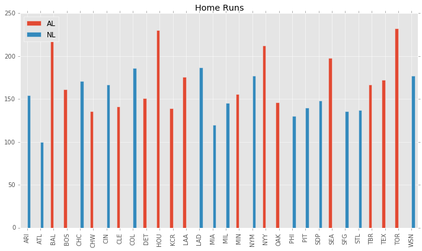

```python
one = df2015.HR[df2015['League'] == 1]
two = df2015.HR[df2015['League'] == 0]
dfhr = pd.DataFrame({'AL': one,
                    'NL': two})
dfhr.plot(kind='bar',title='Home Runs')
plt.tight_layout()
plt.show();
```

## Structural Differences between the AL and NL

There do exist structural differences between the AL and the NL:

- In the AL, pitchers do not bat. Instead, there is a Designated Hitter who does not play in the field (generally these are old guys who are slow but can still hit very well)
- in the NL, there is much more aggressive base running and stolen bases to make up for the fact that pitchers are generally horrible hitters
- In general, NL pitchers have better statistics and AL offense has better statistics

Knowing that there are these structural differences between the two leagues, we cannot simply use all AL teams as our treatment group and all NL teams as our control group. We need to intelligently match them at the feature level. First, let's illustrate that these structural differences exist.

## Why We need Matching

If we are not careful and do not match teams with similar characteristics and just compare NL and AL group statistics, we run the risk of attributing effects to spurious causes. For example, if we find that AL baseball players are more likely to have graying hair then NL baseball players and we didn't match, we would attribute the graying as being an effect of which league. But really its an effect of AL players being older.

```python
mpld3.enable_notebook()
fig = plt.figure(figsize=(8,5))
df2015['BatAge'][df2015['League'] == 1].plot.kde(color='blue',label='AL')
df2015['BatAge'][df2015['League'] == 0].plot.kde(color='red',label='NL')
plt.legend()
plt.xlabel('Average Batter Age')
plt.title("Probability of Average Age of Batters for Teams in each League \n Designated Hitter Effect")
plt.show();
```

[output not shown]

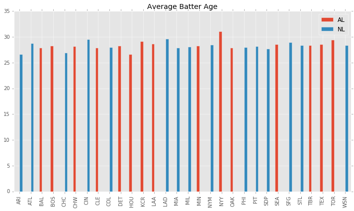

```python
mpld3.disable_notebook()
one = df2015.BatAge[df2015['League'] == 1]
two = df2015.BatAge[df2015['League'] == 0]
dfbatage = pd.DataFrame({'AL': one,
                    'NL': two})
dfbatage.plot(kind='bar',title='Average Batter Age')
plt.tight_layout()
plt.show();
```

## Another Example of Why Careful Matching is Necessary

Some baseball players are very fast and stealing bases is part of their skillset. The number of stolen bases can be taken as a surrogate statistic for how fast a player or team is. But because of the structural differences between the Leagues, there are more stolen bases in national league games. Without matching and performing an analysis, you could be in danger of concluding that being in the national league makes you faster. That is incorrect thinking. What is true is that if you like to steal bases, you are more likely to play in the national league. These types of logical pitfalls careover into the healthcare domain in observational studies. So we need to match teams (or patients) in the treatment group with teams (or patients) in the treatment group.

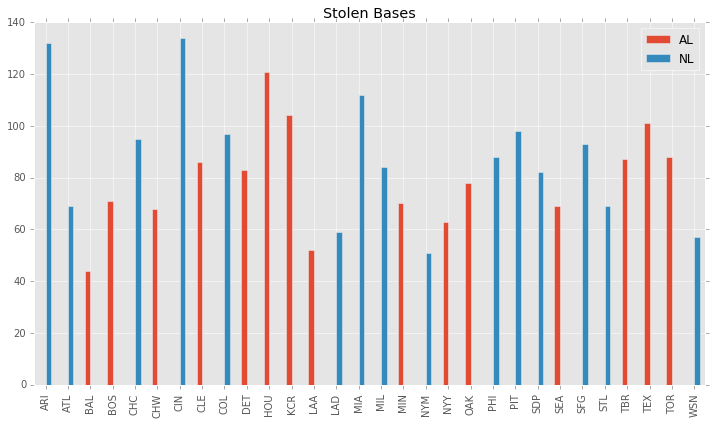

```python
mpld3.disable_notebook()
one = df2015.SB[df2015['League'] == 1]
two = df2015.SB[df2015['League'] == 0]
dfbatage = pd.DataFrame({'AL': one,
                    'NL': two})
dfbatage.plot(kind='bar',title='Stolen Bases')
plt.tight_layout()
plt.show();
```

**Houston used to be a National League team. Became an American League team in 2013**

## Finding nearest neighbors in the 63-dimensional feature space

This brute-force method of finding similar matches in this high-dimensional space is possible for this data set as well as for Big Data sized data sets thanks to a data structure called a KDTree. We need to first transform the numeric data so that all of the different features contribute equally to the eulicidean distance between teams. For example, Stolen Bases for each team are on the order of 80 or so, while Team Batting Average is around 0.270. Without standardzation, Stolen Bases would contribute much more heavily to the distance between teams than Batting Average.

### About standardization

The result of **standardization** (or **Z-score normalization**) is that the features will be rescaled so that they will have the properties of a standard normal distribution with

$\mu = 0$ and $ \sigma = 1$

where $\mu$ is the mean (average) and $\sigma$ is the standard deviation from the mean; standard scores (also called **z** scores) are then calculated as follows:

$ z = \frac{x - \mu}{\sigma} $

```python
xTrain = df2015tree.values
xTrain = StandardScaler().fit_transform(xTrain)
from sklearn.neighbors import KDTree
print(xTrain)
```

```
[[-0.36834548 -0.52867743  0.41934259 ..., -0.09261142 -0.3418629
  -0.06270304]
 [ 0.36834548 -0.06895793  1.03574817 ..., -0.24696377 -0.3418629
   0.55901358]
 [-2.3328547  -0.1838878  -1.14968981 ...,  0.98785509  0.37784847
   0.47930632]
 ...,
 [-0.36834548  0.62062133  0.13915823 ..., -0.71002085 -0.0044982
  -0.68441967]
 [-0.85947278  0.04597195 -0.72941328 ...,  0.67915038  0.19792063
   1.96186136]
 [-1.35060009  0.04597195  0.25123197 ...,  0.98785509  2.22210884
  -0.89165855]]
```

## Results of the Distance calculations

```python
df2015treeleague[['neighbor_1','distance_1',
        'neighbor_2','distance_2',
        'neighbor_3','distance_3']].head(15)
```

| Tm | neighbor_1 | distance_1 | neighbor_2 | distance_2 | neighbor_3 | distance_3 |
| --- | --- | --- | --- | --- | --- | --- |
| BAL | LAA | 6.394846 | MIN | 6.866645 | MIL | 7.276435 |
| BOS | OAK | 7.032256 | TEX | 7.242149 | ARI | 7.887529 |
| CHW | SEA | 6.808050 | SDP | 6.958710 | LAA | 6.965376 |
| CLE | WSN | 9.944493 | LAD | 10.720010 | SFG | 11.093735 |
| DET | BOS | 10.255287 | OAK | 10.705321 | SEA | 10.986538 |
| HOU | CHC | 8.407901 | TBR | 8.599541 | WSN | 8.635173 |
| KCR | SFG | 7.534784 | BOS | 8.406593 | TEX | 8.812390 |
| LAA | BAL | 6.394846 | SDP | 6.702033 | SEA | 6.803413 |
| MIN | BAL | 6.866645 | MIL | 6.938532 | LAA | 7.273833 |
| NYY | BOS | 7.927289 | TEX | 8.135877 | TBR | 9.007414 |
| OAK | BOS | 7.032256 | MIL | 7.331899 | SEA | 7.586802 |
| SEA | LAA | 6.803413 | CHW | 6.808050 | MIL | 7.404514 |
| TBR | LAA | 7.681268 | NYM | 8.269266 | CHW | 8.364929 |
| TEX | BOS | 7.242149 | ARI | 7.962575 | SEA | 8.067707 |
| TOR | NYY | 10.594458 | BOS | 11.137765 | TEX | 11.346220 |

```python
df2015treeleague[['neighbor_1','distance_1',
        'neighbor_2','distance_2',
        'neighbor_3','distance_3']].tail(15)
```

| Tm | neighbor_1 | distance_1 | neighbor_2 | distance_2 | neighbor_3 | distance_3 |
| --- | --- | --- | --- | --- | --- | --- |
| ARI | BOS | 7.887529 | TEX | 7.962575 | CIN | 8.634407 |
| ATL | MIL | 8.472879 | PHI | 8.550684 | MIA | 8.623472 |
| CHC | NYM | 7.497525 | LAD | 7.791098 | WSN | 8.349346 |
| CIN | MIL | 6.629593 | PHI | 7.516125 | SEA | 7.542640 |
| COL | PHI | 8.958295 | MIL | 9.116201 | BOS | 9.567135 |
| LAD | WSN | 7.328003 | NYM | 7.501946 | CHC | 7.791098 |
| MIA | MIL | 6.566040 | SDP | 7.633427 | LAA | 8.210642 |
| MIL | SDP | 4.798345 | PHI | 6.168150 | MIA | 6.566040 |
| NYM | WSN | 6.179332 | CHC | 7.497525 | LAD | 7.501946 |
| PHI | MIL | 6.168150 | CIN | 7.516125 | ATL | 8.550684 |
| PIT | STL | 7.374244 | NYM | 9.359156 | KCR | 9.840934 |
| SDP | MIL | 4.798345 | LAA | 6.702033 | CHW | 6.958710 |
| SFG | KCR | 7.534784 | OAK | 8.648815 | WSN | 8.727379 |
| STL | PIT | 7.374244 | NYM | 7.654085 | CHC | 9.147503 |
| WSN | NYM | 6.179332 | LAD | 7.328003 | LAA | 8.340426 |

## Results of Matching

Looking at only the two closest neighbors and matching AL Teams to any NL teams that qualify as being as one of the two nearest neighbors, we arrive at the following sets of teams:

```python
goodnlteams = list(dd.values())
matches = list(set([item for sublist in goodnlteams for item in sublist]))

treatmentindices = goodalteams
controlindices = matches
print(treatmentindices)
print(controlindices)
```

```
['CHW', 'OAK', 'CLE', 'TBR', 'HOU', 'LAA', 'KCR', 'MIN', 'TEX']
['NYM', 'ARI', 'WSN', 'CHC', 'MIL', 'SDP', 'LAD', 'SFG']
```

## Comparison of distributions of features pre and post matching

We can see the results of matching by comparing how much closer the distributions of different features are between the treatment group (the AL teams that are matched) and the control group (the corresponding matched NL teams) (post matching) than are the corresponding distributions for all AL teams as compared to all NL teams (pre matching). As a metric to compare distributions, use the Kolmogorov-Smirnov statistic on 2 samples. If this K-S statistic is small or the p-value is high, then we cannot reject the hypothesis that the distributions of the two samples are the same (which is what we want in the post matching case).

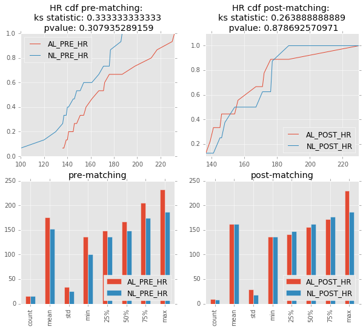

```python
mpld3.disable_notebook()
make_pre_post_plots('HR')
```

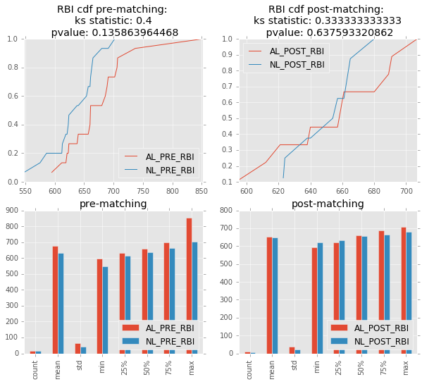

```python
make_pre_post_plots('RBI')
```

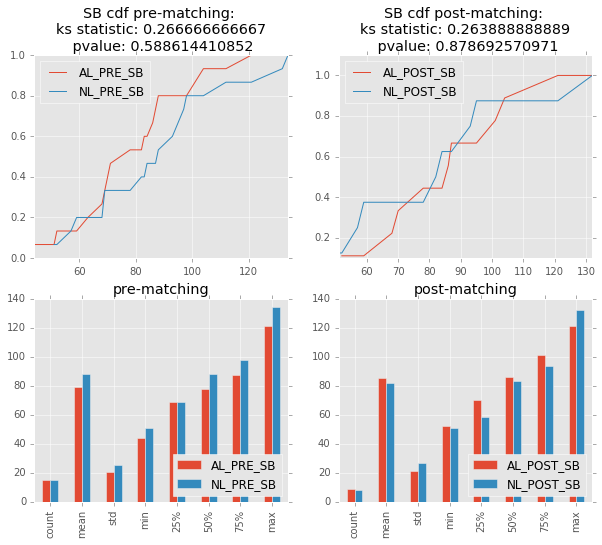

```python
make_pre_post_plots('SB')
```

## Here are the features where the difference between the treatment and control groupings p-values are > .5

- these columns have at least a 50% chance of having the treatment and control groups belonging to the same underlying distribution

```python
dfnice.head(15)
```

|  | pre_ks_stat | pre_pvalue | post_ks_stat | post_pvalue |
| --- | --- | --- | --- | --- |
| G | 0.133333 | 0.998320 | 0.111111 | 1.000000 |
| GS_p | 0.133333 | 0.998320 | 0.111111 | 1.000000 |
| G_p | 0.133333 | 0.998320 | 0.111111 | 1.000000 |
| SLG | 0.400000 | 0.135864 | 0.138889 | 0.999979 |
| cSho_p | 0.200000 | 0.889900 | 0.138889 | 0.999979 |
| AB | 0.200000 | 0.889900 | 0.152778 | 0.999820 |
| OPS | 0.400000 | 0.135864 | 0.194444 | 0.991764 |
| OPS+ | 0.400000 | 0.135864 | 0.194444 | 0.991764 |
| TB | 0.466667 | 0.051467 | 0.208333 | 0.982112 |
| H9_p | 0.200000 | 0.889900 | 0.222222 | 0.966523 |
| ERA+_p | 0.266667 | 0.588614 | 0.250000 | 0.914708 |
| 3B | 0.266667 | 0.588614 | 0.250000 | 0.914708 |
| W-L%_p | 0.400000 | 0.135864 | 0.263889 | 0.878693 |
| W_p | 0.333333 | 0.307935 | 0.263889 | 0.878693 |
| HR | 0.333333 | 0.307935 | 0.263889 | 0.878693 |

```python
dfnice.tail(15)
```

|  | pre_ks_stat | pre_pvalue | post_ks_stat | post_pvalue |
| --- | --- | --- | --- | --- |
| BatAge | 0.200000 | 0.889900 | 0.263889 | 0.878693 |
| SB | 0.266667 | 0.588614 | 0.263889 | 0.878693 |
| L_p | 0.400000 | 0.135864 | 0.263889 | 0.878693 |
| OBP | 0.200000 | 0.889900 | 0.291667 | 0.790719 |
| H_p | 0.200000 | 0.889900 | 0.305556 | 0.741237 |
| BK_p | 0.266667 | 0.588614 | 0.319444 | 0.689803 |
| PAge_p | 0.133333 | 0.998320 | 0.319444 | 0.689803 |
| #Bat | 0.266667 | 0.588614 | 0.319444 | 0.689803 |
| SO9_p | 0.200000 | 0.889900 | 0.333333 | 0.637593 |
| SO_p | 0.200000 | 0.889900 | 0.333333 | 0.637593 |
| HBP_p | 0.266667 | 0.588614 | 0.333333 | 0.637593 |
| R/G | 0.333333 | 0.307935 | 0.333333 | 0.637593 |
| HBP | 0.200000 | 0.889900 | 0.333333 | 0.637593 |
| RBI | 0.400000 | 0.135864 | 0.333333 | 0.637593 |
| R | 0.333333 | 0.307935 | 0.333333 | 0.637593 |

## After Matching, we can now ask interesting questions knowing we are comparing Apples to Apples

Which League has more enthusiastic fans? For each of the teams below, find the attendance for all of the home games in the treatment group (AL teams) and the control group (NL teams)

### We can get the game-level attendance records from http://www.baseball-reference.com

For Example:

```python
IFrame("http://www.baseball-reference.com/teams/KCR/2015-schedule-scores.shtml",width=700, height=350)
```

[interactive chart not shown]

```python
treatsamp = get_group(treatattvals,150000)
controlsamp = get_group(controlattvals,150000)
```

```python
(controlsamp > treatsamp).values.mean()
```

```
0.75262666666666667
```

So we can see here that there is a 75% chance that the National League has a larger attendance at its games than does the American League!

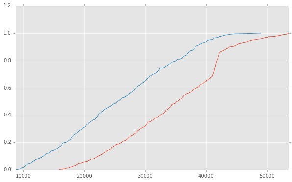

```python
controlsamp.value_counts(normalize=True).sort_index().cumsum().plot();
treatsamp.value_counts(normalize=True).sort_index().cumsum().plot();
```